# CarpentryConnect2019_R

Andrew Stewart

24/06/2019

```r
library(tidyverse)
library(broom)
library(afex)
library(emmeans)
```

# Main task 1 - Simulate data and run t-tests

Let’s imagine we have data from two different groups measuring reaction time (our dependent variable). Group A performed the task under Condition A, Group B under Condition B.

Group A are from a population with a mean = 1000, sd = 20 while Group B are from a population with a mean = 1010, sd = 20

The difference we are investigating equates to a Cohen’s d of .5 as (1010-1000)/20 = .5. This is known as a medium effect size.

First let’s plot an approximation of the population for each sample. Let’s sample 10,000 people from each group. Always remember to `set.seed()` to ensure things are reproducible.

```r
set.seed(1234)
DV <- c(rnorm(10000, 1000, 20), rnorm(10000, 1010, 20))
condition <- c(rep("Condition_A", 10000), rep("Condition_B", 10000))
my_data <- tibble(condition, DV)
```

Let’s plot the data. Below we’re plotting two histogrames over each other.

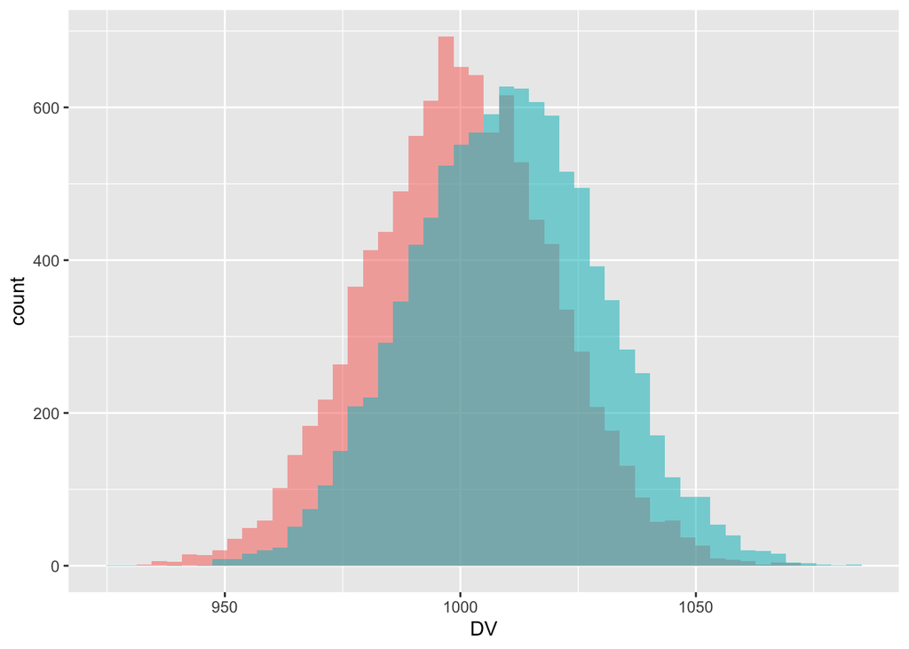

```r
my_data %>%
  ggplot(aes(x = DV, fill = condition, alpha = .5)) +
  geom_histogram(data = filter(my_data, condition == "Condition_A"), bins = 50) +
  geom_histogram(data = filter(my_data, condition == "Condition_B"), bins = 50) +
  guides(fill = FALSE, alpha = FALSE)
```

Now let’s sample 50 individuals from each population. Again, don’t forget to `set.seed()`

```r
set.seed(1234)
DV <- c(rnorm(50, 1000, 20), rnorm(50, 1010, 20))
condition <- c(rep("Condition_A", 50), rep("Condition_B", 50))
my_data <- tibble(condition, DV)
```

Plot the data.

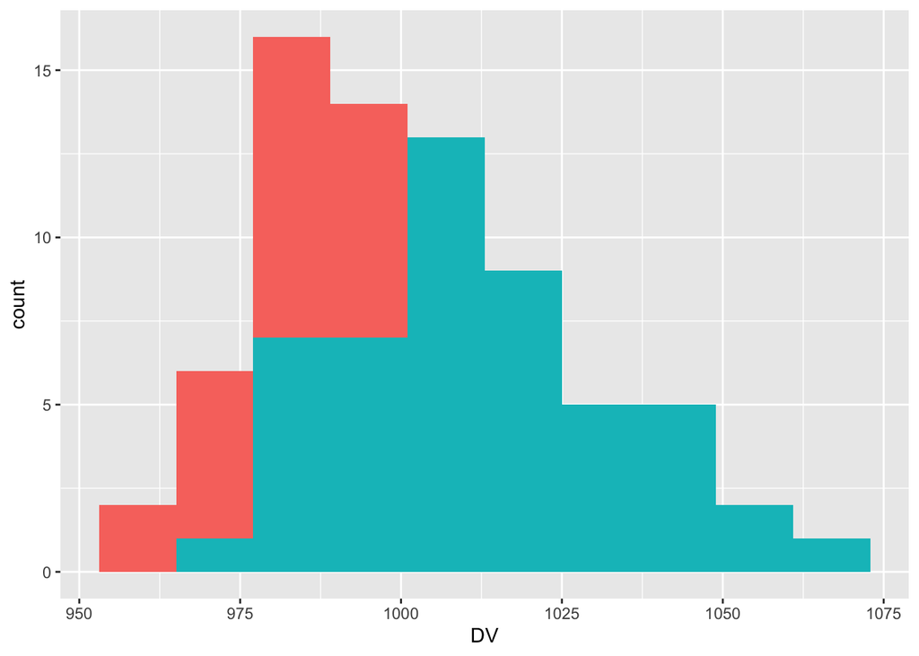

```r
my_data %>%
  ggplot(aes(x = DV, fill = condition)) +
  geom_histogram(data = filter(my_data, condition == "Condition_A"), bins = 10) +
  geom_histogram(data = filter(my_data, condition == "Condition_B"), bins = 10) +
  guides(fill = FALSE, alpha = FALSE)
```

Now let’s generate some summary statistics - in this case the mean and standard deviation grouped by `condition`.

```r
my_data %>%
  group_by(condition) %>%
  summarise(mean_dv = mean(DV), sd_dv = sd(DV))
```

```
## # A tibble: 2 x 3
##   condition   mean_dv sd_dv
##   <chr>         <dbl> <dbl>
## 1 Condition_A    991.  17.7
## 2 Condition_B   1013.  20.7
```

Run a t-test to see if difference Group A vs Group B is significant. It is as p < .05

```r
t.test(my_data[condition == "Condition_A",]$DV, my_data[condition == "Condition_B",]$DV)
```

```
##
##  Welch Two Sample t-test
##
## data:  my_data[condition == "Condition_A", ]$DV and my_data[condition == "Condition_B", ]$DV
## t = -5.6662, df = 95.633, p-value = 1.537e-07
## alternative hypothesis: true difference in means is not equal to 0
## 95 percent confidence interval:
##  -29.50715 -14.19615
## sample estimates:
## mean of x mean of y
##  990.9389 1012.7906
```

Can we get the output in tidy format? Answer: yes…

```r
tidy(t.test(my_data[condition == "Condition_A",]$DV,
            my_data[condition == "Condition_B",]$DV))
```

```
## # A tibble: 1 x 10
##   estimate estimate1 estimate2 statistic p.value parameter conf.low
##      <dbl>     <dbl>     <dbl>     <dbl>   <dbl>     <dbl>    <dbl>
## 1    -21.9      991.     1013.     -5.67 1.54e-7      95.6    -29.5
## # … with 3 more variables: conf.high <dbl>, method <chr>,
## #   alternative <chr>
```

What if we ran 1,000 simulations? Let’s create the data first.

```r
all_data <- NULL
set.seed(1234)
for (i in 1:1000) {
  DV <- c(rnorm(50, 1000, 20), rnorm(50, 1010, 20))
  condition <- c(rep("Condition_A", 50), rep("Condition_B", 50))
  my_data <- tibble(condition, DV, i)
  all_data <- rbind(all_data, my_data)
}
```

Now let’s run 1,000 t-tests.

```r
all_results <- NULL
for (n in 1:1000) {
  my_data_filt <- all_data %>% filter(i == n)
  result <- tidy(t.test(my_data_filt[condition == "Condition_A",]$DV,
                        my_data_filt[condition == "Condition_B",]$DV))
  all_results <- rbind(result, all_results)
}
```

Let’s look at the first few lines of our new tibble corresponding to the t-tests.

```r
head(all_results)
```

```
## # A tibble: 6 x 10
##   estimate estimate1 estimate2 statistic p.value parameter conf.low
##      <dbl>     <dbl>     <dbl>     <dbl>   <dbl>     <dbl>    <dbl>
## 1    -2.49     1006.     1009.    -0.597 5.52e-1      92.9    -10.8
## 2   -14.0       997.     1011.    -3.53  6.28e-4      98.0    -21.8
## 3    -9.37     1002.     1011.    -2.44  1.67e-2      94.7    -17.0
## 4   -13.2      1001.     1014.    -3.19  1.96e-3      90.4    -21.4
## 5    -7.99     1001.     1009.    -2.09  3.88e-2      96.0    -15.6
## 6    -8.83     1004.     1013.    -2.10  3.82e-2      98.0    -17.2
## # … with 3 more variables: conf.high <dbl>, method <chr>,
## #   alternative <chr>
```

How many of these t-tests detect an effect?

```r
count(all_results %>% filter(p.value < .05))
```

```
## # A tibble: 1 x 1
##       n
##   <int>
## 1   683
```

We have 683 significant results out of 1000 simulations - so our experimental power with N = 50 per group to detect a medium effect size (d = .5) is around 68%. So, 32% of the time we fail to detect the effect even though it is present in the population we are sampling from.

# Main task 2 - Linear model with the built-in mtcars dataset

For our dataset of cars, is mile per gallon (mpg) predicted by horsepower (hp)?

First we build our linear model. Don’t forget the assumptions that underlie this approach - firstly, we are assuming that the relationship to be modelled is linear. We also assume that each observation is independent of each other observation - violation of this leads to pseudo-replication and an invalid model.

```r
model <- lm(mpg ~ hp, data = mtcars)
```

Let’s examine the model parameters. The intercept tells us where our line crosses the y-axis when x (hp) is equal to zero. The cofficient estimate associated with hp tells us about the slope of the line - or by how many units y will change for each one unit change in x (hp). In this case, as hp increases by 1, fuel economy drop by 0.06823.

```r
summary(model)
```

```
##
## Call:
## lm(formula = mpg ~ hp, data = mtcars)
##
## Residuals:
##     Min      1Q  Median      3Q     Max
## -5.7121 -2.1122 -0.8854  1.5819  8.2360
##
## Coefficients:
##             Estimate Std. Error t value Pr(>|t|)
## (Intercept) 30.09886    1.63392  18.421  < 2e-16 ***
## hp          -0.06823    0.01012  -6.742 1.79e-07 ***
## ---
## Signif. codes:  0 '***' 0.001 '**' 0.01 '*' 0.05 '.' 0.1 ' ' 1
##
## Residual standard error: 3.863 on 30 degrees of freedom
## Multiple R-squared:  0.6024, Adjusted R-squared:  0.5892
## F-statistic: 45.46 on 1 and 30 DF,  p-value: 1.788e-07
```

Are we violating any assumptions?

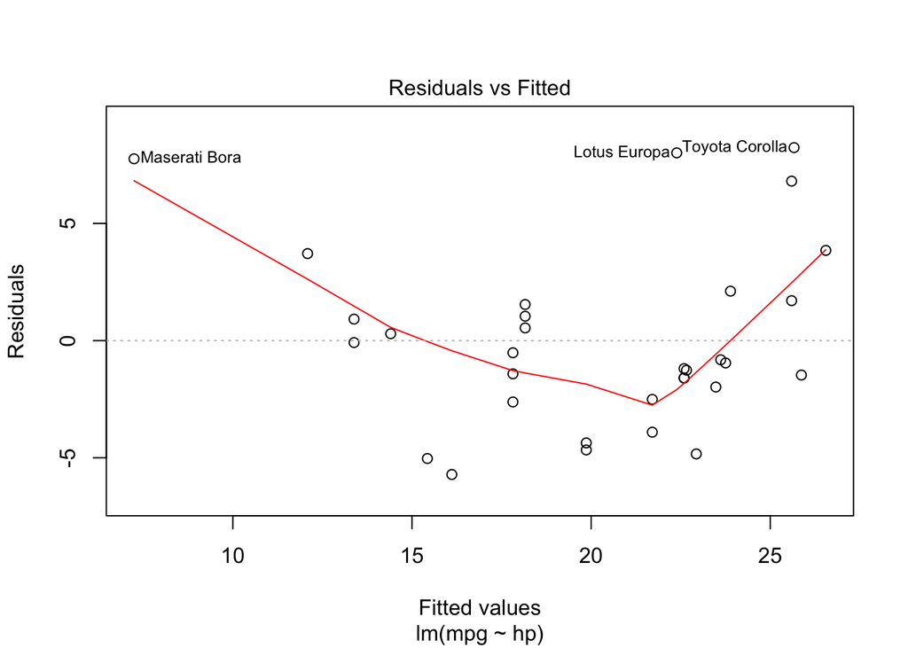

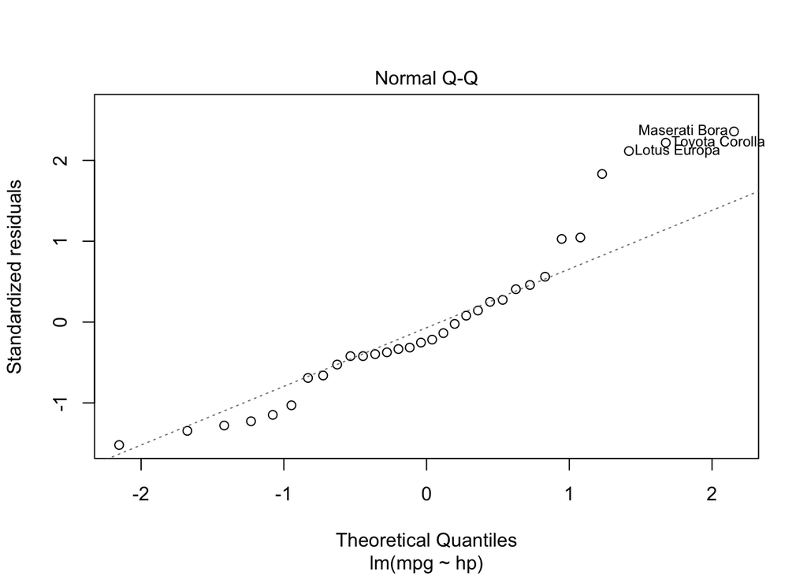

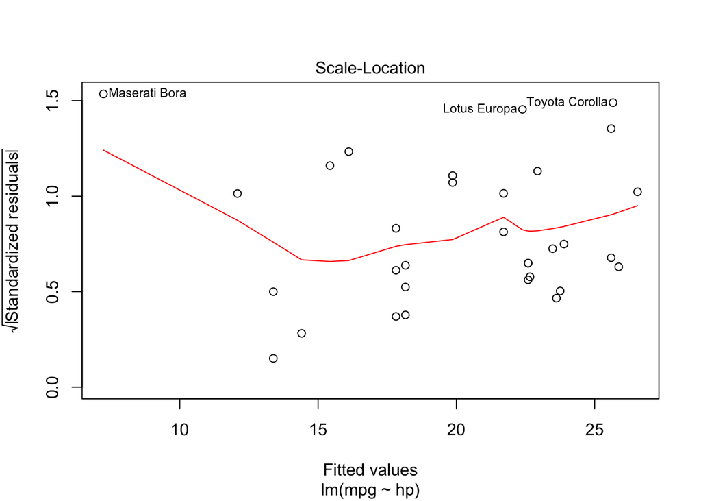

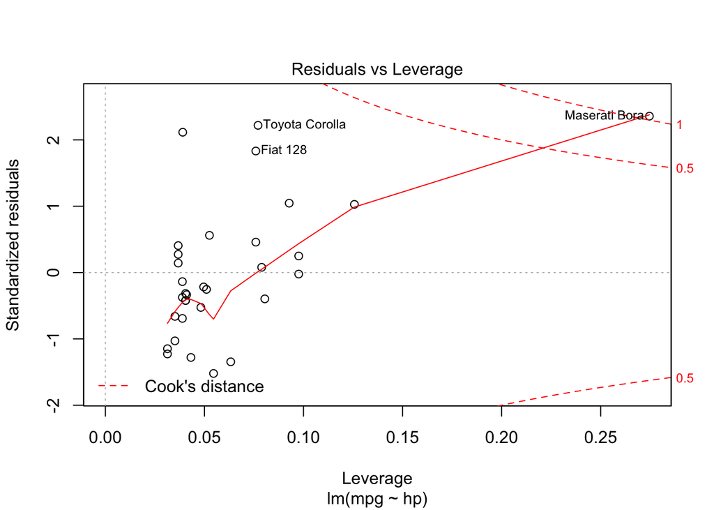

```r
plot(model)
```

We need to convert the rownames to a column variable in order to filter via the following tidyverse approach.

```r
renamed_mtcars <- mtcars %>%
  rownames_to_column()

filtered_mtcars <- filter(renamed_mtcars, (rowname != ("Maserati Bora")) &
                            (rowname != ("Lotus Europa")) &
                            (rowname != ("Toyota Corolla")))
```

We can now create a new linear model based on the filtered dataset. Again, we will check the model parameters and the assumptions.

```r
model <- lm(mpg ~ hp, data = filtered_mtcars)
summary(model)
```

```
##
## Call:
## lm(formula = mpg ~ hp, data = filtered_mtcars)
##
## Residuals:
##     Min      1Q  Median      3Q     Max
## -4.5402 -1.5873 -0.4154  2.0432  7.1897
##
## Coefficients:
##              Estimate Std. Error t value Pr(>|t|)
## (Intercept) 30.086729   1.430261  21.036  < 2e-16 ***
## hp          -0.073885   0.009173  -8.055 1.18e-08 ***
## ---
## Signif. codes:  0 '***' 0.001 '**' 0.01 '*' 0.05 '.' 0.1 ' ' 1
##
## Residual standard error: 2.933 on 27 degrees of freedom
## Multiple R-squared:  0.7061, Adjusted R-squared:  0.6953
## F-statistic: 64.88 on 1 and 27 DF,  p-value: 1.179e-08
```

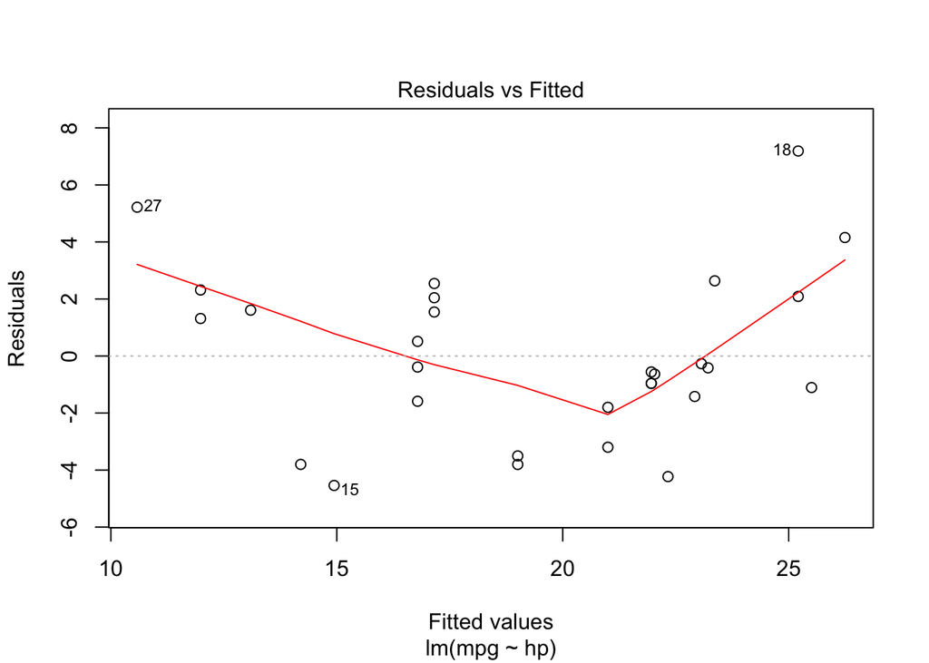

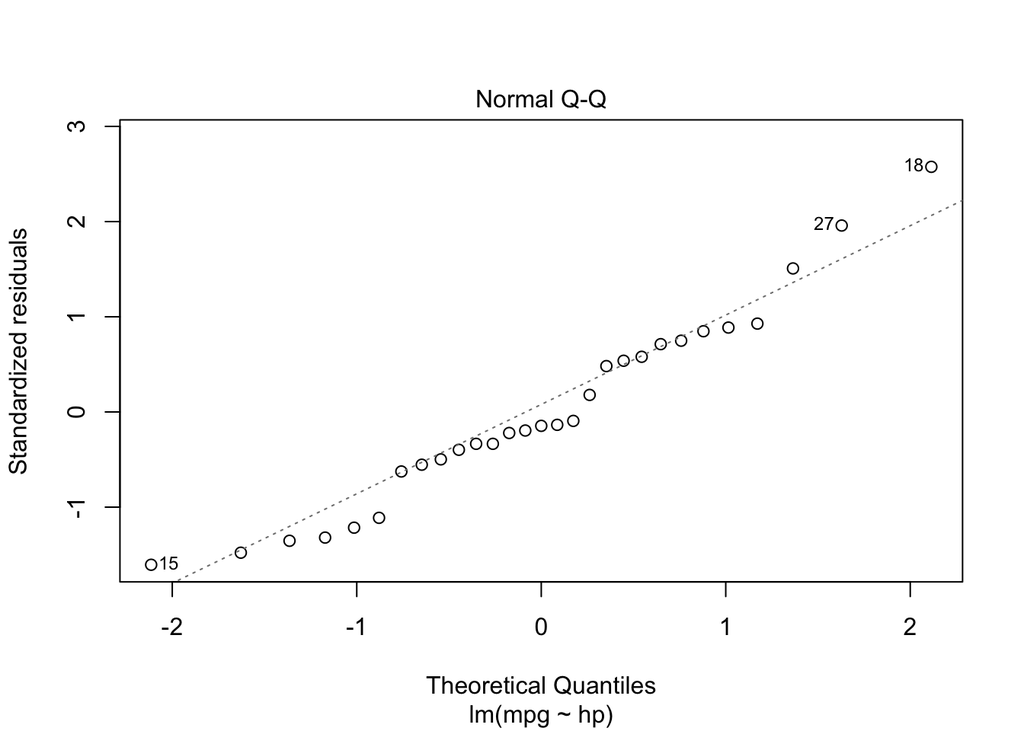

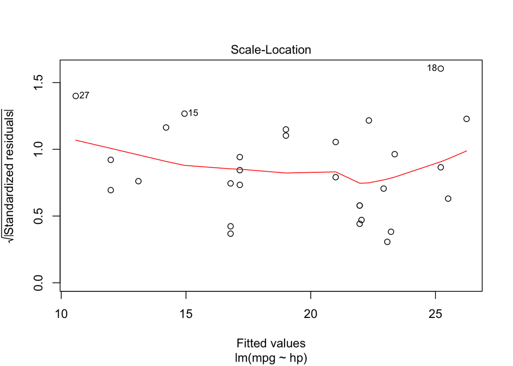

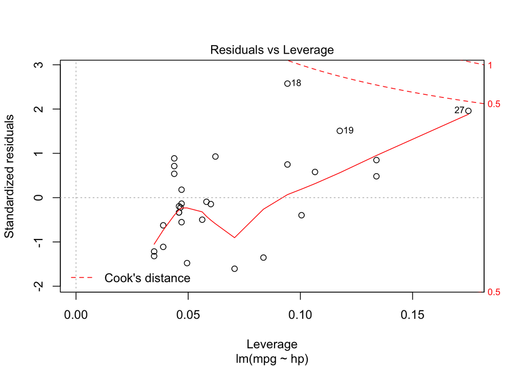

```r
plot(model)
```

Plot the data.

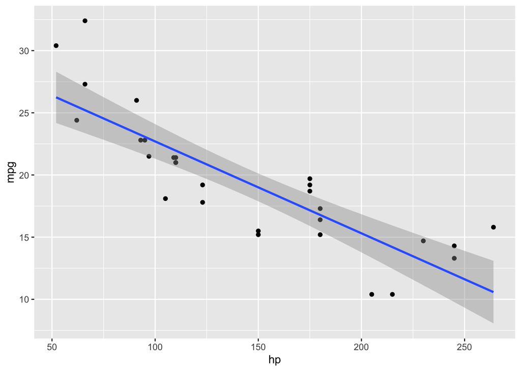

```r
filtered_mtcars %>%
  ggplot(aes(x = hp, y = mpg)) +
  geom_point() +
  geom_smooth(method = "lm")
```

Build another model which simply corresponds to the mean.

```r
model_null <- lm(mpg ~ 1, data = filtered_mtcars)
```

Visualise the mean as a model of our data and the linear model as a model of our data.

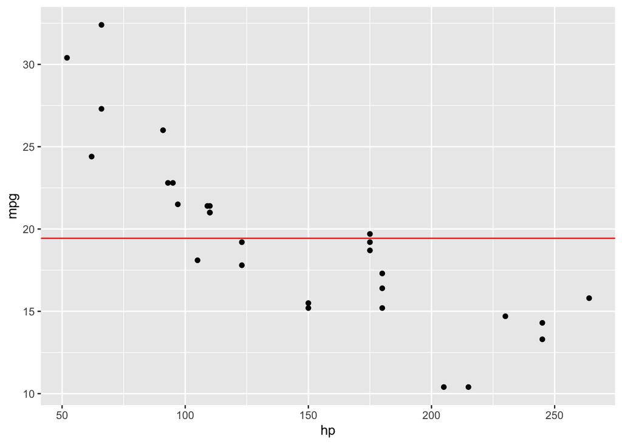

```r
mean_intercept <- mean(filtered_mtcars$mpg)

filtered_mtcars %>%
  ggplot(aes(x = hp, y = mpg)) +
  geom_point() +
  geom_hline(yintercept = mean_intercept, colour = "red")
```

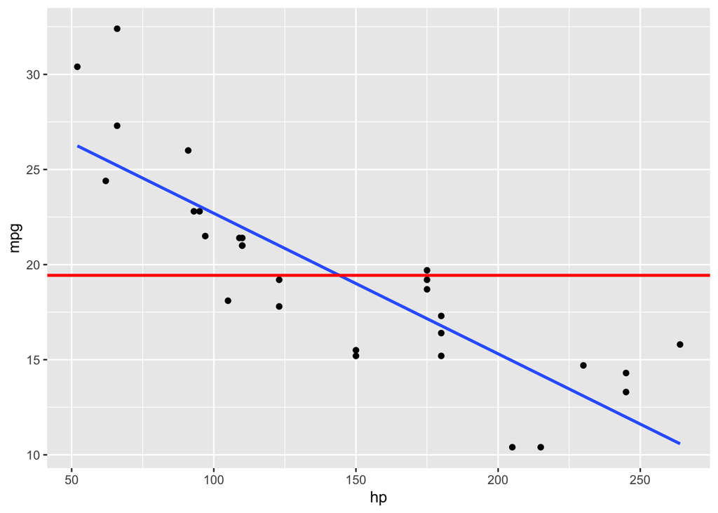

```r
filtered_mtcars %>%
  ggplot(aes(x = hp, y = mpg)) +
  geom_point() +
  geom_smooth(method = "lm", se = FALSE) +
  geom_hline(yintercept = mean_intercept, colour = "red", size = 1)
```

Do the two models differ from each other?

```r
anova(model, model_null)
```

```
## Analysis of Variance Table
##
## Model 1: mpg ~ hp
## Model 2: mpg ~ 1
##   Res.Df    RSS Df Sum of Sq      F    Pr(>F)
## 1     27 232.34
## 2     28 790.67 -1   -558.32 64.881 1.179e-08 ***
## ---
## Signif. codes:  0 '***' 0.001 '**' 0.01 '*' 0.05 '.' 0.1 ' ' 1
```

Answer is ‘yes’ the models differ - the one with the lower RSS (residual sum of squares) is the better fit under the OLS (Ordinary Least Squares) approach.

Let’s generate some descriptives.

```r
filtered_mtcars %>%
  group_by(cyl) %>%
  summarise(mean = mean(mpg), sd = sd(mpg))
```

```
## # A tibble: 3 x 3
##     cyl  mean    sd
##   <dbl> <dbl> <dbl>
## 1     4  25.4  3.93
## 2     6  19.7  1.45
## 3     8  15.1  2.66
```

Now we’re going to conduct an analysis of variance (ANOVA) with one of our variables now set as a factor. We will use aov_4() from the afex package to build our ANOVA model. For anything but the simplest designs, the built-in `aov` function in Base R may mislead as it uses what’s known as dummy coding and Type I Sums of Squares. This can make interaction effects hard to interpret. The afex packages automatically used contrast coding and Type III Sums of Squares in the evaluation of the different model components (i.e., the factors).

We need to convert cyl to a factor first. The we build our model and generate the output. The `nice()` funciton produces the ANOVA output in the format we probably want - but if not, we can also use `summary()`

```r
filtered_mtcars$cyl <- as.factor(filtered_mtcars$cyl)

model_ANOVA <- aov_4(mpg ~ cyl + (1 | rowname), data = filtered_mtcars)
```

```
## Contrasts set to contr.sum for the following variables: cyl
```

```r
nice(model_ANOVA)
```

```
## Anova Table (Type 3 tests)
##
## Response: mpg
##   Effect    df  MSE         F ges p.value
## 1    cyl 2, 26 8.52 33.39 *** .72  <.0001
## ---
## Signif. codes:  0 '***' 0.001 '**' 0.01 '*' 0.05 '+' 0.1 ' ' 1
```

```r
summary(model_ANOVA)
```

```
## Anova Table (Type 3 tests)
##
## Response: mpg
##     num Df den Df    MSE      F     ges    Pr(>F)
## cyl      2     26 8.5211 33.395 0.71979 6.564e-08 ***
## ---
## Signif. codes:  0 '***' 0.001 '**' 0.01 '*' 0.05 '.' 0.1 ' ' 1
```

We have a significant difference *somewhere* between our conditions - the F is the ratio of variance explained by our model to the variance not explained by our model. We now need to conduct pairwise comparisons to determine where the difference lies as ANOVA on its own cannot tell us this for cases where factors have > 2 levels (or if you have interactions between factors).

```r
emmeans(model_ANOVA, pairwise ~ cyl)
```

```
## $emmeans
##  cyl emmean    SE df lower.CL upper.CL
##  4     25.4 0.973 26     23.4     27.4
##  6     19.7 1.103 26     17.5     22.0
##  8     15.1 0.810 26     13.4     16.8
##
## Confidence level used: 0.95
##
## $contrasts
##  contrast estimate   SE df t.ratio p.value
##  4 - 6        5.70 1.47 26 3.876   0.0018
##  4 - 8       10.34 1.27 26 8.166   <.0001
##  6 - 8        4.64 1.37 26 3.387   0.0062
##
## P value adjustment: tukey method for comparing a family of 3 estimates
```

We can see above that each level of the factor `cyl` differs from each other level.

Let’s finish by visualising the data we conducted the ANOVA over - but this time with a violin plot so we can see the shape of the distribution of our data

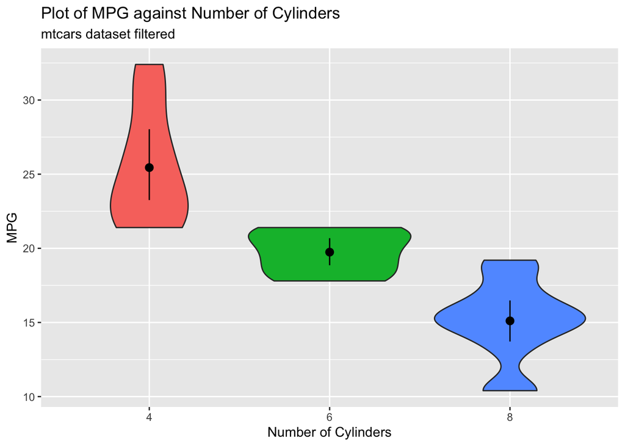

```r
filtered_mtcars %>%
  ggplot(aes(x = cyl, y = mpg, fill = cyl)) +
  geom_violin() +
  stat_summary(fun.data = "mean_cl_boot") +
  labs(x = "Number of Cylinders", y = "MPG",
       title = "Plot of MPG against Number of Cylinders",
       subtitle = "mtcars dataset filtered") +
  guides(fill = FALSE)
```